# assignment-5

1. continued: Extra graphs and info

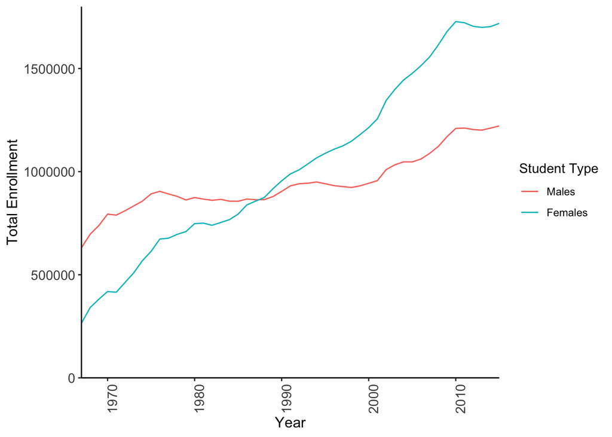

```r
#non regression graphs in case we decide to use them

#total enrollment
total_enroll <- ggplot(grad_enroll, aes(x = Year)) +
  geom_line(aes(y = Total_Males, color = "blue")) +
  geom_line(aes(y = Total_Females, color = "lightblue")) +
   scale_colour_discrete(name = "Student Type", labels = c("Males", "Females")) +
  theme_classic() +
  theme(axis.text.x=element_text(angle=90,hjust=1)) +
  labs(y = "Total Enrollment", x= "Year") +
   theme(axis.text=element_text(size=11))+
  theme(axis.title=element_text(size=12))+
  scale_y_continuous(expand = c(0,0), limits = c(0,1800000))+
  scale_x_continuous(expand = c(0,0), limits = c(1967,2015))

total_enroll
```

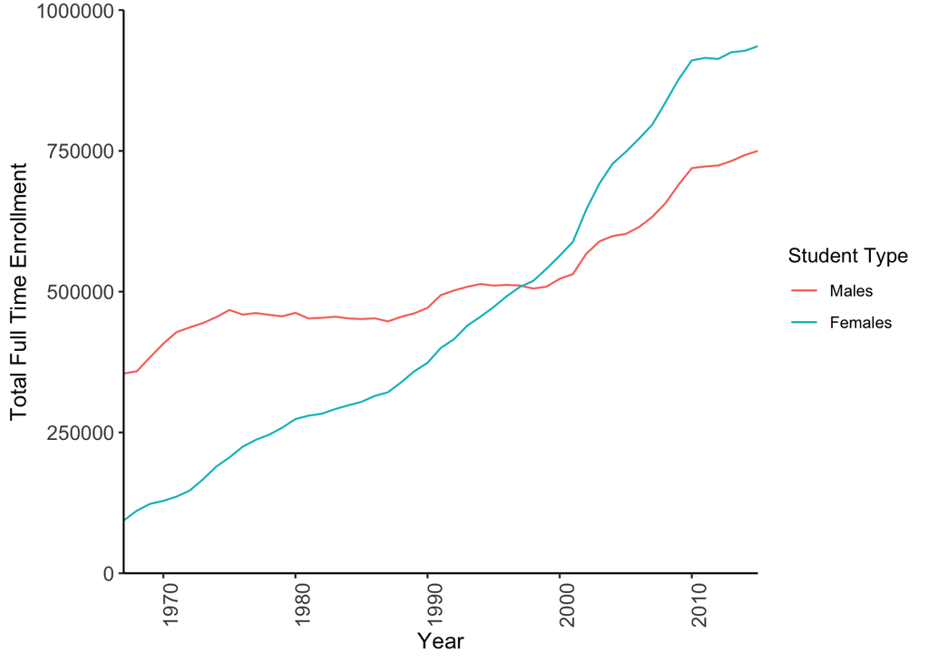

```r
#full time enrollment

full_time <- ggplot(grad_enroll, aes(x = Year)) +
  geom_line(aes(y = Males_full_time, color = "blue")) +
  geom_line(aes(y = Females_full_time, color = "lightblue")) +
  scale_colour_discrete(name = "Student Type", labels = c("Males", "Females")) +
  theme_classic() +
  theme(axis.text.x=element_text(angle=90,hjust=1)) +
  labs(y = "Total Full Time Enrollment", x= "Year") +
   theme(axis.text=element_text(size=11))+
  theme(axis.title=element_text(size=12))+
  scale_y_continuous(expand = c(0,0), limits = c(0,1000000))+
  scale_x_continuous(expand = c(0,0), limits = c(1967,2015))

full_time
```

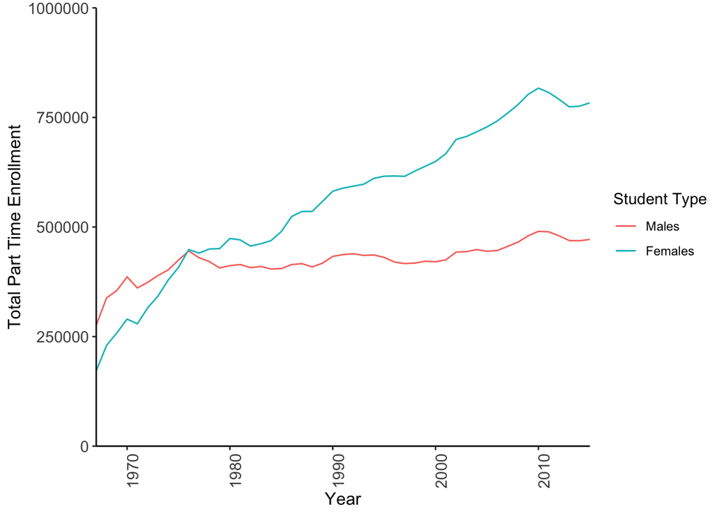

```r
#part time enrollment

part_time <- ggplot(grad_enroll, aes(x = Year)) +
  geom_line(aes(y = Males_part_time, color = "blue")) +
  geom_line(aes(y = Females_part_time, color = "lightblue")) +
  scale_colour_discrete(name = "Student Type", labels = c("Males", "Females")) +
  theme_classic() +
  theme(axis.text.x=element_text(angle=90,hjust=1)) +
  labs(y = "Total Part Time Enrollment", x= "Year") +
   theme(axis.text=element_text(size=11))+
  theme(axis.title=element_text(size=12))+
  scale_y_continuous(expand = c(0,0), limits = c(0,1000000))+
  scale_x_continuous(expand = c(0,0), limits = c(1967,2015))

part_time
```

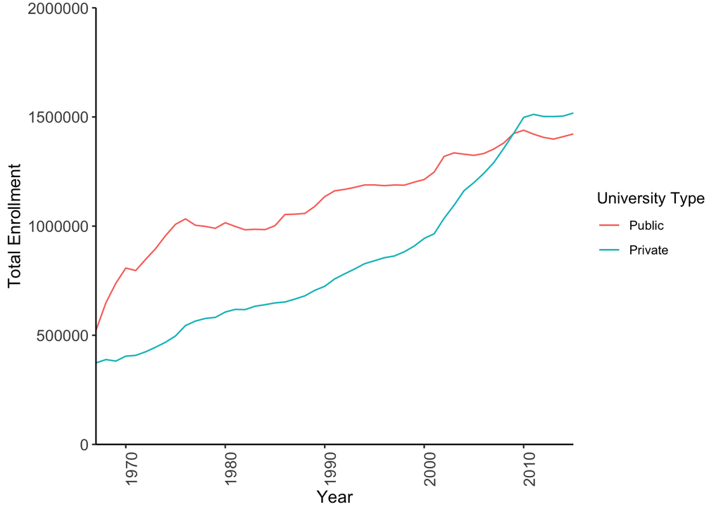

```r
#public vs private

public_private <- ggplot(grad_enroll, aes(x = Year)) +
  geom_line(aes(y = Public, color = "blue")) +
  geom_line(aes(y = Private, color = "lightblue")) +
   scale_colour_discrete(name = "University Type", labels = c("Public", "Private")) +
  theme_classic() +
  theme(axis.text.x=element_text(angle=90,hjust=1)) +
  labs(y = "Total Enrollment", x= "Year") +
   theme(axis.text=element_text(size=11))+
  theme(axis.title=element_text(size=12))+
  scale_y_continuous(expand = c(0,0), limits = c(0,2000000))+
  scale_x_continuous(expand = c(0,0), limits = c(1967,2015))

public_private
```

2. Shifts in female PhD recipients by field (1985, 2000, and 2015). Describe if and how there was a shift in PhDs awarded to females in four fields (Physical and Earth Sciences, Engineering, Education, and Humanities & Arts) in 1985, 2000, and 2015. Describe your results statistically, in a graph or table, and in text. Note: There are several ways that you can interpret this question. You are invited to decide which you think is/are most interesting. Just be really clear about what you are asking/answering in your report.

```r
#chi square?
#proportions of females in those four fields from 1985 to 2000 and from 2000 to 2015

chisq <- chisq.test(phd_prop)
chisq
```

```
##
##  Pearson's Chi-squared test
##
## data:  phd_prop
## X-squared = 2073.3, df = 6, p-value < 2.2e-16
```

```r
rownames(phd_prop) <- c(
"Physical sciences and earth sciences",
"Engineering",
"Education",
"Humanities and arts")
```

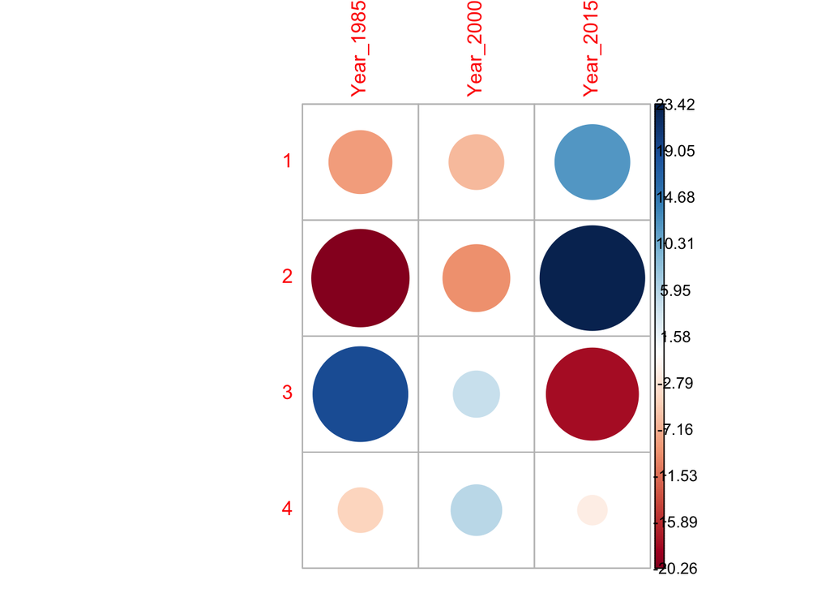

```r
library(corrplot)
corrplot(chisq$residuals, is.cor = FALSE)
```

3. Male and female salaries for starting postdoctoral and other employment positions (2015). Compare median salaries for male and female doctorate recipients in 2015. Answer these two questions: Does median salary differ significantly between male and female starting postdoc positions? Does median salary differ significantly between male and female PhD recipients in non-postdoc employment positions?

```r
#values are for the year 2015

#employment positions

#median femlae salary for starting employment

med_female_employment <- median(median_salary$females_employment)
med_female_employment
```

```
## [1] 71750
```

```r
#median male salary for starting employment

med_male_employment <- median(median_salary$males_employment)
med_male_employment
```

```
## [1] 75167
```

```r
# Compare male and female starting employment salaries using Mann Whitney

test_employment <- wilcox.test(median_salary$males_employment, median_salary$females_employment, paired = TRUE)
test_employment
```

```
##
##  Wilcoxon signed rank test with continuity correction
##
## data:  median_salary$males_employment and median_salary$females_employment
## V = 101, p-value = 0.002572
## alternative hypothesis: true location shift is not equal to 0
```

```r
# Postdoc positions

# median female salary for post doc positions

med_female_postdoc <- median(median_salary$females_postdoc)
med_female_postdoc
```

```
## [1] 45000
```

```r
# median male salary for post doc positions

med_male_postdoc <- median(median_salary$males_postdoc)
med_male_postdoc
```

```
## [1] 48000
```

```r
# Compare male and female startig postdoc salaries using Mann Whitley

test_postdoc <- wilcox.test(median_salary$males_postdoc, median_salary$females_postdoc, paired = TRUE)
test_postdoc
```

```
##
##  Wilcoxon signed rank test with continuity correction
##
## data:  median_salary$males_postdoc and median_salary$females_postdoc
## V = 19.5, p-value = 0.8884
## alternative hypothesis: true location shift is not equal to 0
```

```r
#create boxplot

boxplot_data <- melt(median_salary)
employment_finalized <- ggplot(boxplot_data, aes(x = variable, y = value)) +
  geom_boxplot() +
  labs(y = "Annual Salary ($)", x = "") +
  geom_jitter(width = 0.1, aes(color = variable)) +
  scale_color_manual(values = c("darkblue","lightblue", "darkred", "red"),
                     labels=c("Employed Males","Employed Females","Male Postdocs","Female Postdocs"),
                     name = "Group") +
  scale_x_discrete(labels=c("Employed Males","Employed Females","Male Postdocs","Female Postdocs")) +
  theme_classic() +
   theme(text = element_text(family = "Times New Roman"))

employment_finalized
```

[figure not shown]

```r
#Based on our results, there was not a significant difference in male and female salaires in 2015 in postdoc appointments, but there was in traditional employment settings (V = 101, p = 0.0025). Actual difference in median salaries for employment positions was $3,417. Actual difference in median salaries for post doc positions was $3,000
```

**Figure 2. Salaries for Female and Male doctorate recipients (2015).** Annual salaries for men and women in traditional employment positions and in postdoctorate positions. bars indictae median values, boxes indiciates interquartile range. Data points indiciate individual observations.